# wine_analyze_1754656389

```python
import pandas as pd
```

```python
red = pd.read_csv('https://archive.ics.uci.edu/ml/machine-learning-databases/wine-quality/winequality-red.csv', sep=';')
white = pd.read_csv('https://archive.ics.uci.edu/ml/machine-learning-databases/wine-quality/winequality-white.csv', sep=';')
red.head()
```

|  | fixed acidity | volatile acidity | citric acid | residual sugar | chlorides | free sulfur dioxide | total sulfur dioxide | density | pH | sulphates | alcohol | quality |
| --- | --- | --- | --- | --- | --- | --- | --- | --- | --- | --- | --- | --- |
| 0 | 7.4 | 0.70 | 0.00 | 1.9 | 0.076 | 11.0 | 34.0 | 0.9978 | 3.51 | 0.56 | 9.4 | 5 |
| 1 | 7.8 | 0.88 | 0.00 | 2.6 | 0.098 | 25.0 | 67.0 | 0.9968 | 3.20 | 0.68 | 9.8 | 5 |
| 2 | 7.8 | 0.76 | 0.04 | 2.3 | 0.092 | 15.0 | 54.0 | 0.9970 | 3.26 | 0.65 | 9.8 | 5 |
| 3 | 11.2 | 0.28 | 0.56 | 1.9 | 0.075 | 17.0 | 60.0 | 0.9980 | 3.16 | 0.58 | 9.8 | 6 |
| 4 | 7.4 | 0.70 | 0.00 | 1.9 | 0.076 | 11.0 | 34.0 | 0.9978 | 3.51 | 0.56 | 9.4 | 5 |

```python
white.head()
```

|  | fixed acidity | volatile acidity | citric acid | residual sugar | chlorides | free sulfur dioxide | total sulfur dioxide | density | pH | sulphates | alcohol | quality |
| --- | --- | --- | --- | --- | --- | --- | --- | --- | --- | --- | --- | --- |
| 0 | 7.0 | 0.27 | 0.36 | 20.7 | 0.045 | 45.0 | 170.0 | 1.0010 | 3.00 | 0.45 | 8.8 | 6 |
| 1 | 6.3 | 0.30 | 0.34 | 1.6 | 0.049 | 14.0 | 132.0 | 0.9940 | 3.30 | 0.49 | 9.5 | 6 |
| 2 | 8.1 | 0.28 | 0.40 | 6.9 | 0.050 | 30.0 | 97.0 | 0.9951 | 3.26 | 0.44 | 10.1 | 6 |
| 3 | 7.2 | 0.23 | 0.32 | 8.5 | 0.058 | 47.0 | 186.0 | 0.9956 | 3.19 | 0.40 | 9.9 | 6 |
| 4 | 7.2 | 0.23 | 0.32 | 8.5 | 0.058 | 47.0 | 186.0 | 0.9956 | 3.19 | 0.40 | 9.9 | 6 |

```python
red['type'] = 'red'
white['type'] = 'white'
df = pd.concat([red, white], axis = 0).reset_index(drop = True)
df
```

|  | fixed acidity | volatile acidity | citric acid | residual sugar | chlorides | free sulfur dioxide | total sulfur dioxide | density | pH | sulphates | alcohol | quality | type |
| --- | --- | --- | --- | --- | --- | --- | --- | --- | --- | --- | --- | --- | --- |
| 0 | 7.4 | 0.70 | 0.00 | 1.9 | 0.076 | 11.0 | 34.0 | 0.99780 | 3.51 | 0.56 | 9.4 | 5 | red |
| 1 | 7.8 | 0.88 | 0.00 | 2.6 | 0.098 | 25.0 | 67.0 | 0.99680 | 3.20 | 0.68 | 9.8 | 5 | red |
| 2 | 7.8 | 0.76 | 0.04 | 2.3 | 0.092 | 15.0 | 54.0 | 0.99700 | 3.26 | 0.65 | 9.8 | 5 | red |
| 3 | 11.2 | 0.28 | 0.56 | 1.9 | 0.075 | 17.0 | 60.0 | 0.99800 | 3.16 | 0.58 | 9.8 | 6 | red |
| 4 | 7.4 | 0.70 | 0.00 | 1.9 | 0.076 | 11.0 | 34.0 | 0.99780 | 3.51 | 0.56 | 9.4 | 5 | red |
| ... | ... | ... | ... | ... | ... | ... | ... | ... | ... | ... | ... | ... | ... |
| 6492 | 6.2 | 0.21 | 0.29 | 1.6 | 0.039 | 24.0 | 92.0 | 0.99114 | 3.27 | 0.50 | 11.2 | 6 | white |
| 6493 | 6.6 | 0.32 | 0.36 | 8.0 | 0.047 | 57.0 | 168.0 | 0.99490 | 3.15 | 0.46 | 9.6 | 5 | white |
| 6494 | 6.5 | 0.24 | 0.19 | 1.2 | 0.041 | 30.0 | 111.0 | 0.99254 | 2.99 | 0.46 | 9.4 | 6 | white |
| 6495 | 5.5 | 0.29 | 0.30 | 1.1 | 0.022 | 20.0 | 110.0 | 0.98869 | 3.34 | 0.38 | 12.8 | 7 | white |
| 6496 | 6.0 | 0.21 | 0.38 | 0.8 | 0.020 | 22.0 | 98.0 | 0.98941 | 3.26 | 0.32 | 11.8 | 6 | white |

6497 rows × 13 columns

```python
target = 'quality'
```

В объединённом датасете содержится **6497 строк и 12 признаков**.  
Каждая строка — это одно наблюдение (партия вина), а признаки — физико-химические характеристики и оценка качества.

```python
print(df.info())
print(df.describe())
```

```
<class 'pandas.core.frame.DataFrame'>
RangeIndex: 6497 entries, 0 to 6496
Data columns (total 13 columns):
 #   Column                Non-Null Count  Dtype
---  ------                --------------  -----
 0   fixed acidity         6497 non-null   float64
 1   volatile acidity      6497 non-null   float64
 2   citric acid           6497 non-null   float64
 3   residual sugar        6497 non-null   float64
 4   chlorides             6497 non-null   float64
 5   free sulfur dioxide   6497 non-null   float64
 6   total sulfur dioxide  6497 non-null   float64
 7   density               6497 non-null   float64
 8   pH                    6497 non-null   float64
 9   sulphates             6497 non-null   float64
 10  alcohol               6497 non-null   float64
 11  quality               6497 non-null   int64
 12  type                  6497 non-null   object
dtypes: float64(11), int64(1), object(1)
memory usage: 660.0+ KB
None
       fixed acidity  volatile acidity  citric acid  residual sugar  \
count    6497.000000       6497.000000  6497.000000     6497.000000
mean        7.215307          0.339666     0.318633        5.443235
std         1.296434          0.164636     0.145318        4.757804
min         3.800000          0.080000     0.000000        0.600000
25%         6.400000          0.230000     0.250000        1.800000
50%         7.000000          0.290000     0.310000        3.000000
75%         7.700000          0.400000     0.390000        8.100000
max        15.900000          1.580000     1.660000       65.800000

         chlorides  free sulfur dioxide  total sulfur dioxide      density  \
count  6497.000000          6497.000000           6497.000000  6497.000000
mean      0.056034            30.525319            115.744574     0.994697
std       0.035034            17.749400             56.521855     0.002999
min       0.009000             1.000000              6.000000     0.987110
25%       0.038000            17.000000             77.000000     0.992340
50%       0.047000            29.000000            118.000000     0.994890
75%       0.065000            41.000000            156.000000     0.996990
max       0.611000           289.000000            440.000000     1.038980

                pH    sulphates      alcohol      quality
count  6497.000000  6497.000000  6497.000000  6497.000000
mean      3.218501     0.531268    10.491801     5.818378
std       0.160787     0.148806     1.192712     0.873255
min       2.720000     0.220000     8.000000     3.000000
25%       3.110000     0.430000     9.500000     5.000000
50%       3.210000     0.510000    10.300000     6.000000
75%       3.320000     0.600000    11.300000     6.000000
max       4.010000     2.000000    14.900000     9.000000
```

```python
import matplotlib.pyplot as plt
import seaborn as sns
```

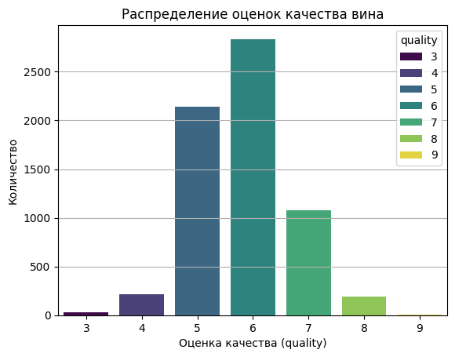

```python
sns.countplot(data = df, x = 'quality', palette = 'viridis', hue = 'quality')
plt.title('Распределение оценок качества вина')
plt.xlabel('Оценка качества (quality)')
plt.ylabel('Количество')
plt.grid(axis='y')
plt.show()
```

Целевая переменная `quality` принимает значения от 3 до 9 включительно.  
Распределение классов **несбалансированное**: большая часть вин получает оценку 5, 6 или 7.  
Экстремальные значения (например, 3 или 9) встречаются крайне редко.

**анализ корреляций между признаками и целевой переменной**

```python
numeric = df.select_dtypes(include = ['int', 'float'])
numeric
```

|  | fixed acidity | volatile acidity | citric acid | residual sugar | chlorides | free sulfur dioxide | total sulfur dioxide | density | pH | sulphates | alcohol | quality |
| --- | --- | --- | --- | --- | --- | --- | --- | --- | --- | --- | --- | --- |
| 0 | 7.4 | 0.70 | 0.00 | 1.9 | 0.076 | 11.0 | 34.0 | 0.99780 | 3.51 | 0.56 | 9.4 | 5 |
| 1 | 7.8 | 0.88 | 0.00 | 2.6 | 0.098 | 25.0 | 67.0 | 0.99680 | 3.20 | 0.68 | 9.8 | 5 |
| 2 | 7.8 | 0.76 | 0.04 | 2.3 | 0.092 | 15.0 | 54.0 | 0.99700 | 3.26 | 0.65 | 9.8 | 5 |
| 3 | 11.2 | 0.28 | 0.56 | 1.9 | 0.075 | 17.0 | 60.0 | 0.99800 | 3.16 | 0.58 | 9.8 | 6 |
| 4 | 7.4 | 0.70 | 0.00 | 1.9 | 0.076 | 11.0 | 34.0 | 0.99780 | 3.51 | 0.56 | 9.4 | 5 |
| ... | ... | ... | ... | ... | ... | ... | ... | ... | ... | ... | ... | ... |
| 6492 | 6.2 | 0.21 | 0.29 | 1.6 | 0.039 | 24.0 | 92.0 | 0.99114 | 3.27 | 0.50 | 11.2 | 6 |
| 6493 | 6.6 | 0.32 | 0.36 | 8.0 | 0.047 | 57.0 | 168.0 | 0.99490 | 3.15 | 0.46 | 9.6 | 5 |
| 6494 | 6.5 | 0.24 | 0.19 | 1.2 | 0.041 | 30.0 | 111.0 | 0.99254 | 2.99 | 0.46 | 9.4 | 6 |
| 6495 | 5.5 | 0.29 | 0.30 | 1.1 | 0.022 | 20.0 | 110.0 | 0.98869 | 3.34 | 0.38 | 12.8 | 7 |
| 6496 | 6.0 | 0.21 | 0.38 | 0.8 | 0.020 | 22.0 | 98.0 | 0.98941 | 3.26 | 0.32 | 11.8 | 6 |

6497 rows × 12 columns

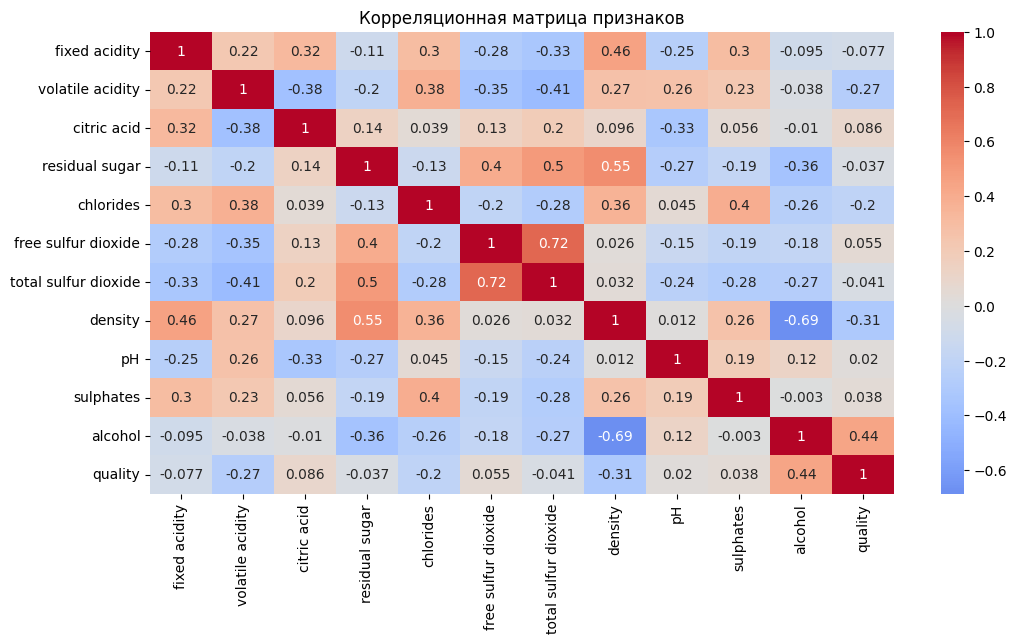

```python
plt.figure(figsize = (12, 6))
sns.heatmap(df.corr(numeric_only = True), cmap = 'coolwarm', annot = True, center = 0)
plt.title('Корреляционная матрица признаков')
plt.show()
```

```python
df.corr(numeric_only=True)['quality'].sort_values(ascending=False)
```

|  | quality |
| --- | --- |
| quality | 1.000000 |
| alcohol | 0.444319 |
| citric acid | 0.085532 |
| free sulfur dioxide | 0.055463 |
| sulphates | 0.038485 |
| pH | 0.019506 |
| residual sugar | -0.036980 |
| total sulfur dioxide | -0.041385 |
| fixed acidity | -0.076743 |
| chlorides | -0.200666 |
| volatile acidity | -0.265699 |
| density | -0.305858 |

**dtype:** float64

По результатам анализа:

alcohol — наиболее положительно коррелирует с качеством (~0.44)

Многие признаки между собой слабо коррелируют (что хорошо для деревьев)

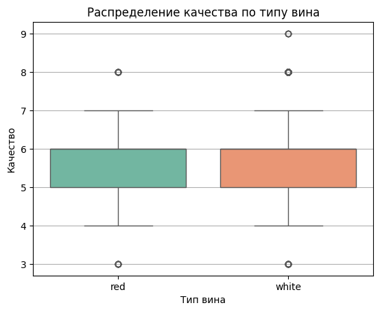

```python
sns.boxplot(data = df, x = 'type', y = 'quality', palette = 'Set2')
plt.title('Распределение качества по типу вина')
plt.xlabel('Тип вина')
plt.ylabel('Качество')
plt.grid(axis='y')
plt.show()
```

Белое вино (white) в среднем получает чуть более высокую оценку качества, чем красное (red)

Однако распределения пересекаются, и нельзя по type точно предсказать quality

Этот признак всё равно может быть полезным при обучении модели

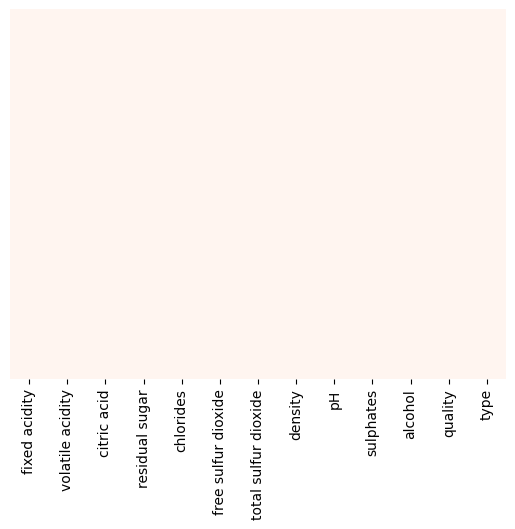

```python
sns.heatmap(df.isnull(), cbar = False, yticklabels = False, cmap = 'Reds')
plt.show()
```

Пропущенных значений нет => идем дальше)

```python
df_encoded = pd.get_dummies(df, columns = ['type'], drop_first = True)
df_encoded
```

|  | fixed acidity | volatile acidity | citric acid | residual sugar | chlorides | free sulfur dioxide | total sulfur dioxide | density | pH | sulphates | alcohol | quality | type_white |
| --- | --- | --- | --- | --- | --- | --- | --- | --- | --- | --- | --- | --- | --- |
| 0 | 7.4 | 0.70 | 0.00 | 1.9 | 0.076 | 11.0 | 34.0 | 0.99780 | 3.51 | 0.56 | 9.4 | 5 | False |
| 1 | 7.8 | 0.88 | 0.00 | 2.6 | 0.098 | 25.0 | 67.0 | 0.99680 | 3.20 | 0.68 | 9.8 | 5 | False |
| 2 | 7.8 | 0.76 | 0.04 | 2.3 | 0.092 | 15.0 | 54.0 | 0.99700 | 3.26 | 0.65 | 9.8 | 5 | False |
| 3 | 11.2 | 0.28 | 0.56 | 1.9 | 0.075 | 17.0 | 60.0 | 0.99800 | 3.16 | 0.58 | 9.8 | 6 | False |
| 4 | 7.4 | 0.70 | 0.00 | 1.9 | 0.076 | 11.0 | 34.0 | 0.99780 | 3.51 | 0.56 | 9.4 | 5 | False |
| ... | ... | ... | ... | ... | ... | ... | ... | ... | ... | ... | ... | ... | ... |
| 6492 | 6.2 | 0.21 | 0.29 | 1.6 | 0.039 | 24.0 | 92.0 | 0.99114 | 3.27 | 0.50 | 11.2 | 6 | True |
| 6493 | 6.6 | 0.32 | 0.36 | 8.0 | 0.047 | 57.0 | 168.0 | 0.99490 | 3.15 | 0.46 | 9.6 | 5 | True |
| 6494 | 6.5 | 0.24 | 0.19 | 1.2 | 0.041 | 30.0 | 111.0 | 0.99254 | 2.99 | 0.46 | 9.4 | 6 | True |
| 6495 | 5.5 | 0.29 | 0.30 | 1.1 | 0.022 | 20.0 | 110.0 | 0.98869 | 3.34 | 0.38 | 12.8 | 7 | True |
| 6496 | 6.0 | 0.21 | 0.38 | 0.8 | 0.020 | 22.0 | 98.0 | 0.98941 | 3.26 | 0.32 | 11.8 | 6 | True |

6497 rows × 13 columns

```python
X = df_encoded.drop(['quality'], axis = 1)
y = df_encoded.quality
```

```python
from sklearn.model_selection import train_test_split
```

```python
X_train, X_test, y_train, y_test = train_test_split(X, y, random_state = 42, test_size = 0.2)
```

```python
from sklearn.tree import DecisionTreeRegressor
from sklearn.metrics import r2_score, mean_absolute_error, mean_squared_error
```

```python
model = DecisionTreeRegressor(random_state = 42)
model.fit(X_train, y_train)
```

```
DecisionTreeRegressor(random_state=42)
```

```python
y_pred = model.predict(X_test)
mae = mean_absolute_error(y_test, y_pred)
mse = mean_squared_error(y_test, y_pred)
r2 = r2_score(y_test, y_pred)

print(f"MAE: {mae:.3f}")
print(f"MSE: {mse:.3f}")
print(f"R²: {r2:.3f}")
```

```
MAE: 0.508
MSE: 0.729
R²: 0.013
```

DecisionTreeRegressor без настройки — переобучается.

Он запоминает тренировочные примеры, но плохо обобщает.

Почти никакой пользы при тестировании (R² ≈ 0).

```python
from sklearn.model_selection import GridSearchCV
```

```python
reg = DecisionTreeRegressor(random_state = 42)
param_grid = {
    'max_depth': [3,5,7,10,13,None],
    'min_samples_split': [2,5,10,15],
    'min_samples_leaf': [1,2,4,6]
}
```

```python
grid_search = GridSearchCV(reg,
                           param_grid = param_grid,
                           cv = 5,
                           scoring = 'neg_mean_squared_error',
                           n_jobs = -1,
                           verbose = 1)
grid_search.fit(X_train, y_train)
```

```
Fitting 5 folds for each of 96 candidates, totalling 480 fits
```

```
GridSearchCV(cv=5, estimator=DecisionTreeRegressor(random_state=42), n_jobs=-1,
             param_grid={'max_depth': [3, 5, 7, 10, 13, None],
                         'min_samples_leaf': [1, 2, 4, 6],
                         'min_samples_split': [2, 5, 10, 15]},
             scoring='neg_mean_squared_error', verbose=1)
```

```python
grid_search.best_params_
```

```
{'max_depth': 5, 'min_samples_leaf': 6, 'min_samples_split': 2}
```

```python
best_model = grid_search.best_estimator_
y_pred = best_model.predict(X_test)
print("MAE:", mean_absolute_error(y_test, y_pred))
print("MSE:", mean_squared_error(y_test, y_pred))
print("R²:", r2_score(y_test, y_pred))
```

```
MAE: 0.5701833592090931
MSE: 0.5542661574325674
R²: 0.24951783923887094
```

### ✅ Результаты настройки DecisionTreeRegressor через GridSearchCV

Наилучшая модель была найдена при следующих параметрах:

- `max_depth = 5`
- `min_samples_split = 2`
- `min_samples_leaf = 6`

Оценка качества модели на тестовой выборке:

- **MAE (Mean Absolute Error)**: 0.571
- **MSE (Mean Squared Error)**: 0.554
- **R² (Коэффициент детерминации)**: 0.25

#### 🔍 Интерпретация

- **R² = 0.25** — это означает, что модель объясняет около 25% дисперсии в данных. Это **неплохой, но скромный результат**, который можно улучшить с помощью более мощных алгоритмов.
- DecisionTreeRegressor даёт интерпретируемую, но склонную к переобучению модель. Даже после настройки гиперпараметров его качество ограничено.

```python
from sklearn.ensemble import RandomForestRegressor
```

```python
rfg = RandomForestRegressor(random_state = 42)
rfg.fit(X_train, y_train)
```

```
RandomForestRegressor(random_state=42)
```

```python
y_pred_rf = rfg.predict(X_test)
mae = mean_absolute_error(y_test, y_pred_rf)
mse = mean_squared_error(y_test, y_pred_rf)
r2 = r2_score(y_test, y_pred_rf)

print(f"MAE: {mae:.3f}")
print(f"MSE: {mse:.3f}")
print(f"R²: {r2:.3f}")
```

```
MAE: 0.437
MSE: 0.370
R²: 0.499
```

```python
rf = RandomForestRegressor(random_state = 42)
grid_params_rfg = {
    'max_depth': [None, 4, 8, 11],
    'min_samples_split': [2,6,10],
    'n_estimators': [50, 100, 200],
    'max_features': ['log2', 'sqrt']
}
grid_search_rf = GridSearchCV(rf,
                              param_grid=grid_params_rfg,
                              cv = 5,
                              scoring = 'neg_mean_squared_error',
                              verbose = 2,
                              n_jobs = -1)
grid_search_rf.fit(X_train, y_train)
```

```
Fitting 5 folds for each of 72 candidates, totalling 360 fits
```

```
GridSearchCV(cv=5, estimator=RandomForestRegressor(random_state=42), n_jobs=-1,
             param_grid={'max_depth': [None, 4, 8, 11],
                         'max_features': ['log2', 'sqrt'],
                         'min_samples_split': [2, 6, 10],
                         'n_estimators': [50, 100, 200]},
             scoring='neg_mean_squared_error', verbose=2)
```

```python
grid_search_rf.best_params_
```

```
{'max_depth': None,
 'max_features': 'log2',
 'min_samples_split': 2,
 'n_estimators': 200}
```

```python
best_model_rd = grid_search_rf.best_estimator_
y_pred_rf = best_model_rd.predict(X_test)
mae = mean_absolute_error(y_test, y_pred_rf)
mse = mean_squared_error(y_test, y_pred_rf)
r2 = r2_score(y_test, y_pred_rf)

print(f"MAE: {mae:.3f}")
print(f"MSE: {mse:.3f}")
print(f"R²: {r2:.3f}")
```

```
MAE: 0.428
MSE: 0.353
R²: 0.522
```

## Random Forest Regressor

На этом этапе мы применили модель `RandomForestRegressor` для решения задачи регрессии. Основные цели заключались в:

- улучшении качества предсказаний по сравнению с Decision Tree;
- подборе гиперпараметров с помощью `GridSearchCV`;
- интерпретации результатов модели.

Модель показала улучшение по сравнению с базовым деревом решений. Особенно заметен рост коэффициента **детерминации (R²)**, что указывает на лучшее объяснение дисперсии целевой переменной.

**Вывод**

`Random Forest` позволил значительно улучшить результаты за счёт ансамблирования нескольких деревьев решений. Это делает модель более устойчивой к переобучению и позволяет лучше обобщать данные на тестовой выборке.

```python
from sklearn.ensemble import GradientBoostingRegressor
```

```python
gbr = GradientBoostingRegressor(random_state = 42)

param_grid_gbr = {
    'n_estimators': [100, 200],
    'max_depth': [None, 2,5, 7],
    'subsample': [1.0, 0.8],
    'learning_rate': [0.1, 0.05]
}

grid_search_gb = GridSearchCV(gbr,
                              param_grid = param_grid_gbr,
                              cv = 5,
                              scoring = 'neg_mean_squared_error',
                              verbose = 2,
                              n_jobs = -1)

grid_search_gb.fit(X_train, y_train)
```

```
Fitting 5 folds for each of 32 candidates, totalling 160 fits
```

```
GridSearchCV(cv=5, estimator=GradientBoostingRegressor(random_state=42),
             n_jobs=-1,
             param_grid={'learning_rate': [0.1, 0.05],
                         'max_depth': [None, 2, 5, 7],
                         'n_estimators': [100, 200], 'subsample': [1.0, 0.8]},
             scoring='neg_mean_squared_error', verbose=2)
```

```python
grid_search_gb.best_params_
```

```
{'learning_rate': 0.05,
 'max_depth': None,
 'n_estimators': 100,
 'subsample': 0.8}
```

```python
best_model_gb = grid_search_gb.best_estimator_
y_pred_gbr = best_model_gb.predict(X_test)
print("MAE:", mean_absolute_error(y_test, y_pred_gbr))
print("MSE:", mean_squared_error(y_test, y_pred_gbr))
print("R²:", r2_score(y_test, y_pred_gbr))
```

```
MAE: 0.403997030323432
MSE: 0.38199975959056864
R²: 0.48276833946398734
```

```python
from xgboost import XGBRegressor
```

```python
xgb = XGBRegressor(random_state = 42)
param_grid_xgb = {
    'n_estimators': [100, 200],
    'max_depth': [None, 2, 4, 7],
    'subsample': [1.0, 0.8],
    'learning_rate': [0.1, 0.05],
}
grid_search_xgb = GridSearchCV(xgb,
                               param_grid = param_grid_xgb,
                               cv = 5,
                               scoring = 'neg_mean_squared_error',
                               n_jobs = -1,
                               verbose = 2)
grid_search_xgb.fit(X_train, y_train)
```

```
Fitting 5 folds for each of 32 candidates, totalling 160 fits
```

```
GridSearchCV(cv=5,
             estimator=XGBRegressor(base_score=None, booster=None,
                                    callbacks=None, colsample_bylevel=None,
                                    colsample_bynode=None,
                                    colsample_bytree=None, device=None,
                                    early_stopping_rounds=None,
                                    enable_categorical=False, eval_metric=None,
                                    feature_types=None, feature_weights=None,
                                    gamma=None, grow_policy=None,
                                    importance_type=None,
                                    interaction_constraints=None...
                                    max_cat_to_onehot=None, max_delta_step=None,
                                    max_depth=None, max_leaves=None,
                                    min_child_weight=None, missing=nan,
                                    monotone_constraints=None,
                                    multi_strategy=None, n_estimators=None,
                                    n_jobs=None, num_parallel_tree=None, ...),
             n_jobs=-1,
             param_grid={'learning_rate': [0.1, 0.05],
                         'max_depth': [None, 2, 4, 7],
                         'n_estimators': [100, 200], 'subsample': [1.0, 0.8]},
             scoring='neg_mean_squared_error', verbose=2)
```

```python
grid_search_xgb.best_params_
```

[output not shown]

```python
best_model_xgb = grid_search_xgb.best_estimator_
y_pred_xgb = best_model_xgb.predict(X_test)
print("MAE:", mean_absolute_error(y_test, y_pred_xgb))
print("MSE:", mean_squared_error(y_test, y_pred_xgb))
print("R²:", r2_score(y_test, y_pred_xgb))
```

```
MAE: 0.4412251114845276
MSE: 0.37598586082458496
R²: 0.49091118574142456
```

```python
# Усреднённый блендинг
y_pred_blend = (y_pred_rf + y_pred_gbr + y_pred_xgb) / 3

print("Blended MAE:", mean_absolute_error(y_test, y_pred_blend))
print("Blended MSE:", mean_squared_error(y_test, y_pred_blend))
print("Blended R²:", r2_score(y_test, y_pred_blend))
```

```
Blended MAE: 0.41560763994192135
Blended MSE: 0.3528303857812679
Blended R²: 0.5222639759752539
```

📊 Вывод по модели блендинга В рамках эксперимента был реализован усреднённый блендинг трёх моделей: `RandomForestRegressor, GradientBoostingRegressor и XGBRegressor`. **Цель** — улучшить качество предсказания целевой переменной путём объединения сильных моделей

[output not shown]

```python
from sklearn.linear_model import Ridge
from sklearn.ensemble import StackingRegressor
```

```python
base_models = [
    ('rf', RandomForestRegressor(**grid_search_rf.best_params_, random_state=42)),
    ('gb', GradientBoostingRegressor(**grid_search_gb.best_params_, random_state = 42)),
    ('xgb', XGBRegressor(**grid_search_xgb.best_params_, random_state = 42))
]
# Мета-модель (на выходе)
meta_model = Ridge()

stack_model = StackingRegressor(
    estimators = base_models,
    final_estimator = meta_model,
    cv = 5,
    n_jobs = -1
)
stack_model.fit(X_train, y_train)
```

```
StackingRegressor(cv=5,
                  estimators=[('rf',
                               RandomForestRegressor(max_features='log2',
                                                     n_estimators=200,
                                                     random_state=42)),
                              ('gb',
                               GradientBoostingRegressor(learning_rate=0.05,
                                                         max_depth=None,
                                                         random_state=42,
                                                         subsample=0.8)),
                              ('xgb',
                               XGBRegressor(base_score=None, booster=None,
                                            callbacks=None,
                                            colsample_bylevel=None,
                                            colsample_bynode=None,
                                            colsample_bytree=None, dev...
                                            grow_policy=None,
                                            importance_type=None,
                                            interaction_constraints=None,
                                            learning_rate=0.1, max_bin=None,
                                            max_cat_threshold=None,
                                            max_cat_to_onehot=None,
                                            max_delta_step=None, max_depth=7,
                                            max_leaves=None,
                                            min_child_weight=None, missing=nan,
                                            monotone_constraints=None,
                                            multi_strategy=None,
                                            n_estimators=200, n_jobs=None,
                                            num_parallel_tree=None, ...))],
                  final_estimator=Ridge(), n_jobs=-1)
```

```python
y_pred_stack = stack_model.predict(X_test)
print("MAE:", mean_absolute_error(y_test, y_pred_stack))
print("MSE:", mean_squared_error(y_test, y_pred_stack))
print("R²:", r2_score(y_test, y_pred_stack))
```

```
MAE: 0.41345306008108573
MSE: 0.34873165027632924
R²: 0.5278137066179893
```

В качестве базовых моделей использовались:

**RandomForestRegressor**

**GradientBoostingRegressor**

**XGBRegressor**

**Мета-модель: Ridge**

После применения стекинга модель показала следующие метрики:

`MAE: 0.413`

```python
importances = best_model_xgb.feature_importances_
feat_names = X_train.columns
importance_df = pd.DataFrame({'Feature': feat_names, 'Importance': importances})
importance_df = importance_df.sort_values(by='Importance', ascending=False)
importance_df
```

|  | Feature | Importance |
| --- | --- | --- |
| 10 | alcohol | 0.274666 |
| 11 | type_white | 0.127932 |
| 1 | volatile acidity | 0.084148 |
| 5 | free sulfur dioxide | 0.076918 |
| 9 | sulphates | 0.071980 |
| 6 | total sulfur dioxide | 0.061233 |
| 8 | pH | 0.059070 |
| 3 | residual sugar | 0.057937 |
| 7 | density | 0.053509 |
| 4 | chlorides | 0.052214 |
| 2 | citric acid | 0.048765 |
| 0 | fixed acidity | 0.031627 |

### Важность признаков (Feature Importance)

Чтобы понять, какие признаки оказывают наибольшее влияние на модель, мы визуализировали важность признаков, рассчитанную с помощью `XGBoost`. Это позволяет интерпретировать модель и понять, какие факторы наиболее значимы для предсказания целевой переменной.

График важности признаков показывает, что наиболее важными являются **alcohol, type_white, volatile_activity**.

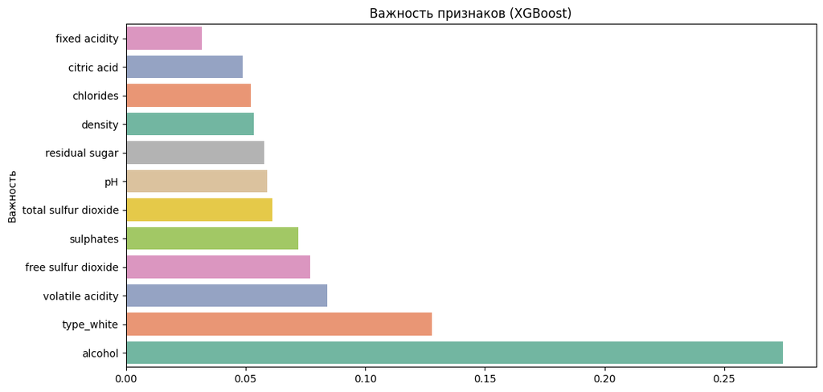

```python
plt.figure(figsize = (12,6))
sns.barplot(data = importance_df, x = 'Importance', y = 'Feature', palette = 'Set2')
plt.gca().invert_yaxis()
plt.title('Важность признаков (XGBoost)')
plt.ylabel('Важность')
plt.xlabel('')
plt.show()
```

### 📌 2. Визуализация ошибок

### Анализ ошибок модели

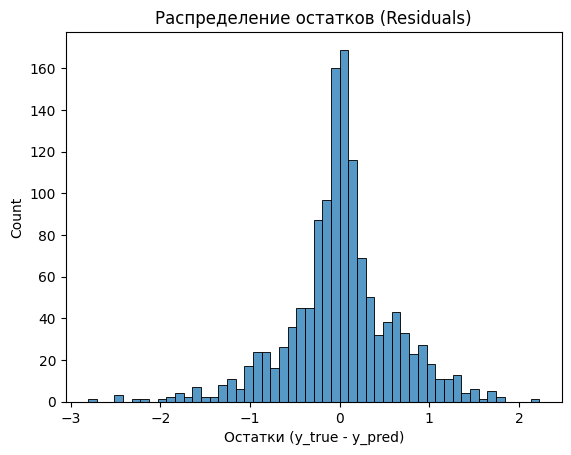

```python
residuals = y_test-y_pred_stack
sns.histplot(residuals)
plt.title('Распределение остатков (Residuals)')
plt.xlabel('Остатки (y_true - y_pred)')
plt.show()
```